# In Class Activity

[figure not shown]

This in-class activity will get you set up for initial use of GitHub in RStudio.

## In Class Activities

### Logistics & Registration

The following steps should get you to be configuring your github account properly.

1. Go to https://github.com and register as a user. Your user name will be used publically, so choose one *appropriately*.
2. Save your username and password in a secure location (password manager…).
3. Configure a personal access token (Settings -> Developer Settings -> Personal Access Token). Make sure to select a long enough time frame (rest of the calendar year) that you do not have to go back and do this again too frequently.
4. Save the personal access token with in a secure location (password manager…).
5. Feel free to add a photo and other information for your account. You can link this from your LinkedIn account or other social media sources, it is a verifiable repository for artifacts of intellectual content.

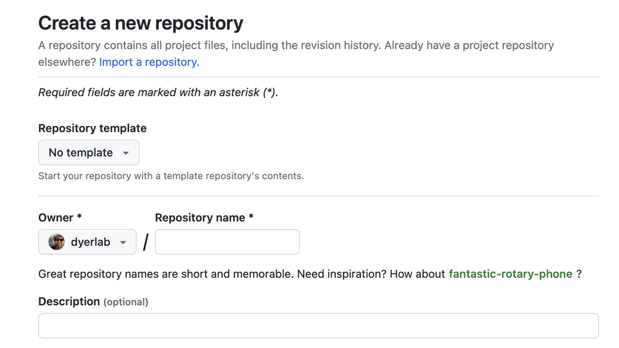

1. Log into your GitHub account.
2. Select “Repositories” from the menu and then create a New one with the following characteristics.
   - No Template
   - Pick a publically visible name for your first test repository and put it into the `Repository name` field.
   - Add a short description.
   - Make it `Public`
   - Add a `README` file.
   - For `.gitignore` select `R` as the language.
   - Explore a license (add one or not, it is up to you).
3. Create the repository.

### Editing Online

The [GitHub](https://github.com) web interface allows you to edit content (add and delete as well) online. I recommend this to mostly quick items. To edit, select the file and then click on the ✏️ icon in the title pane for the file. Once you are done editing, you must `commit` the changes you’ve made (and put in good description of what you did).

1. Select the `README.md` file and edit it.
2. Add a paragraph of text to the file.
3. Commit the changes (give a commit message) and see how the content you added to the file changes the overall repository front page.